# Data Analytics

## Homework 4

### Name: 李權桓 ID:10546004

# q1

$$ S_1 = \begin{vmatrix} 1 & 0 & 0 \\ 0 & 1 & 0 \\ 0 & 0 & 1 \\ \end{vmatrix} $$$$ \begin{vmatrix} S_1 \end{vmatrix} = 1\begin{vmatrix} 1 & 0 \\ 0 & 1 \\ \end{vmatrix} - 0\begin{vmatrix} 0 & 0 \\ 0 & 1 \\ \end{vmatrix} + 0\begin{vmatrix} 0 & 1 \\ 0 & 0 \\ \end{vmatrix}=1 $$$$ tr[S_1]=1+1+1=3 $$

$$ S_2 = \begin{vmatrix} 1 & -\frac{1}{2} & -\frac{1}{2} \\ -\frac{1}{2} & 1 & -\frac{1}{2} \\ -\frac{1}{2} & -\frac{1}{2} & 1 \\ \end{vmatrix} $$$$ \begin{vmatrix} S_1 \end{vmatrix} = 1\begin{vmatrix} 1 & -\frac{1}{2} \\ -\frac{1}{2} & 1 \\ \end{vmatrix} + \frac{1}{2} \begin{vmatrix} -\frac{1}{2} & -\frac{1}{2} \\ -\frac{1}{2} & 1 \\ \end{vmatrix} -\frac{1}{2}\begin{vmatrix} -\frac{1}{2} & 1 \\ -\frac{1}{2} & -\frac{1}{2} \\ \end{vmatrix}=1-\frac{4}{4}=0 $$$$ tr[S_1]=1+1+1=3 $$

# q2

Try: covariance matrix 3x3 determinant

$$ \begin{align*} \begin{vmatrix} S_{11} & S_{12} & S_{13} \\ S_{21} & S_{22} & S_{23} \\ S_{31} & S_{32} & S_{33} \\ \end{vmatrix} &= S_{11}\begin{vmatrix} S_{22} & S_{23} \\ S_{32} & S_{33} \\ \end{vmatrix} - S_{12}\begin{vmatrix} S_{21} & S_{23} \\ S_{31} & S_{33} \\ \end{vmatrix} + S_{13}\begin{vmatrix} S_{21} & S_{22} \\ S_{31} & S_{32} \\ \end{vmatrix} \\&= S_{11}(S_{22}S_{33}-S_{23}^2) - S_{12}(S_{21}S_{33}-S_{23}S_{31})+ S_{13}(S_{21}S_{32}-S_{22}S_{31}) \\ &= 3S_{11}S_{22}S_{33} - S_{11}S_{23}^2 -S_{22}S_{13}^2 -S_{33}S_{12}^2 \\ \end{align*} $$

If the result devides $S_{11}S_{22}S_{33}$, it will get $|R|$

Let $V$ as $diag(varaince)$, $$ S=V^{\frac{1}{2}}R V^{\frac{1}{2}} $$

[output not shown]

# q3

## q3a

$$ \bar{y_1}=0.766+0.508+0.438+0.161 = 1.873 $$

```python
0.766+0.508+0.438+0.161
```

```
1.873
```

$$ \begin{aligned} Var(y_1) &=v(x_1+x_2)+v(x_3+x_4)+2cov(x_1+x_2, x_3+x_4) \\ &= v(x_1)+v(x_2)+2cov(x_1, x_2)+ v(x_3)+v(x_4)+2cov(x_3, x_4) + 2\{cov(x_1, x_3)+cov(x_1, x_4)+cov(x_2, x_3)+cov(x_2, x_4)\} \\ &= 3.914 \end{aligned} $$

note: $$ cov(x_1+x_2, x_3+x_4) = cov(x_1, x_3)+cov(x_1, x_4)+cov(x_2, x_3)+cov(x_2, x_4) $$

```python
.856+.568+2*.635+.171+.043+2*.039+2*(.173+.096+.128+.067)
```

```
3.9139999999999997
```

## q3b

$$ \bar{y_2}=0.766-0.508 = 0.258 $$

```python
0.766-0.508
```

```
0.258
```

$$ Var(y_2)= v(x_1)+v(x_2)-2cov(x_1, x_2)=0.154 $$

```python
.856+.568-2*.635
```

```
0.15399999999999991
```

## q3c

$$ \begin{align*} cov(y_1, y_2) &= cov(y_1, x_1 - x_2) \\ &= cov(y_1, x_1 ) - cov(y_1, x_2) \\ &= \begin{pmatrix} cov(x_1, x_1) + \\ cov(x_2, x_1) + \\ cov(x_3, x_1) + \\ cov(x_4, x_1) \\ \end{pmatrix} - \begin{pmatrix} cov(x_1, x_2) + \\ cov(x_2, x_2) + \\ cov(x_3, x_2) + \\ cov(x_4, x_2) \\ \end{pmatrix} &= 0.363 \end{align*} $$

```python
(.856+.635+.173+.096)-(.635+.568+.127+.067)
```

```
0.36300000000000043
```

# q4

```python
import numpy as np
from numpy.linalg import inv

a =np.matrix([[2,8,6,8],[12,9,9,10]])
b = np.matrix([a[0].mean() -7, a[1].mean() -11])
s = np.cov(a)

t_sqrt  = a.shape[1] * b *inv(s)*b.T
print('s is \n', inv(s))
print('The q4a T^2 is ' , t_sqrt)
```

```
s is
 [[0.40909091 0.68181818]
 [0.68181818 1.63636364]]
The q4a T^2 is  [[13.63636364]]
```

## q4b

$$ T^2 \sim T^2_{p,n-1} = \frac{p(n-1)}{n-p}F_{ p,n-p} =\frac{2 \times 3}{2}F_{ 2,2} $$

```python
from scipy.stats import f
print('F test statistic is ',  f.ppf(1-.05,2,2)*3)
```

```
F test statistic is  56.99999999999994
```

## q4c

$$ T^2 < T^2_{p,n-1} $$

Do not reject H_0

```python
import pandas as pd
import numpy as np
import seaborn as sns
import matplotlib.pyplot as plt
from scipy import stats
import re
import io
from statsmodels.multivariate.manova import MANOVA
import statsmodels.api as sm
```

# q5

```python
col_names = ['F_Length','F_Width','F_Height',
             'M_Length','M_Width','M_Height']
# read text file into pandas DataFrame
filename = "HW4_q5data.txt"
# df = pd.read_fwf(,header=None,names = col_names,delimiter = "\s")
# df
ll = []
with io.open(filename, mode="r", encoding="utf-8") as f:
    for line in f:
        # print(line.split())
        ll.append([float(i) for i in line.split()])
df = pd.DataFrame(ll,columns=col_names)
df
```

|  | F_Length | F_Width | F_Height | M_Length | M_Width | M_Height |
| --- | --- | --- | --- | --- | --- | --- |
| 0 | 98.0 | 81.0 | 38.0 | 93.0 | 74.0 | 37.0 |
| 1 | 103.0 | 84.0 | 38.0 | 94.0 | 78.0 | 35.0 |
| 2 | 103.0 | 86.0 | 42.0 | 96.0 | 80.0 | 35.0 |
| 3 | 105.0 | 86.0 | 42.0 | 101.0 | 84.0 | 39.0 |
| 4 | 109.0 | 88.0 | 44.0 | 102.0 | 85.0 | 38.0 |
| 5 | 123.0 | 92.0 | 50.0 | 103.0 | 81.0 | 37.0 |
| 6 | 123.0 | 95.0 | 46.0 | 104.0 | 83.0 | 39.0 |
| 7 | 133.0 | 99.0 | 51.0 | 106.0 | 83.0 | 39.0 |
| 8 | 133.0 | 102.0 | 51.0 | 107.0 | 82.0 | 38.0 |
| 9 | 133.0 | 102.0 | 51.0 | 112.0 | 89.0 | 40.0 |
| 10 | 134.0 | 100.0 | 48.0 | 113.0 | 88.0 | 40.0 |
| 11 | 136.0 | 102.0 | 49.0 | 114.0 | 86.0 | 40.0 |
| 12 | 138.0 | 98.0 | 51.0 | 116.0 | 90.0 | 43.0 |
| 13 | 138.0 | 99.0 | 51.0 | 117.0 | 90.0 | 41.0 |
| 14 | 141.0 | 105.0 | 53.0 | 117.0 | 91.0 | 41.0 |
| 15 | 147.0 | 108.0 | 57.0 | 119.0 | 93.0 | 41.0 |
| 16 | 149.0 | 107.0 | 55.0 | 120.0 | 89.0 | 40.0 |
| 17 | 153.0 | 107.0 | 56.0 | 120.0 | 93.0 | 44.0 |
| 18 | 155.0 | 115.0 | 63.0 | 121.0 | 95.0 | 42.0 |
| 19 | 155.0 | 117.0 | 60.0 | 125.0 | 93.0 | 45.0 |
| 20 | 158.0 | 115.0 | 62.0 | 127.0 | 96.0 | 45.0 |
| 21 | 159.0 | 118.0 | 63.0 | 128.0 | 95.0 | 45.0 |
| 22 | 162.0 | 124.0 | 61.0 | 131.0 | 95.0 | 46.0 |
| 23 | 177.0 | 132.0 | 67.0 | 135.0 | 106.0 | 47.0 |

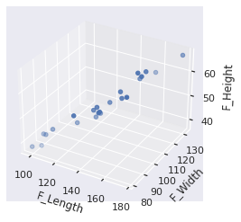

```python
# plot female data in 3d
sns.set(style = "darkgrid")

fig = plt.figure()
ax = fig.add_subplot(111, projection = '3d')

x = df['F_Length']
y = df['F_Width']
z = df['F_Height']

ax.set_xlabel("F_Length")
ax.set_ylabel("F_Width")
ax.set_zlabel("F_Height")

ax.scatter(x, y, z)

plt.show()
```

```python
a = pd.DataFrame(df.iloc[:,:3].to_numpy(), columns=['Length','Width','Height'])
b = pd.DataFrame(df.iloc[:,3:].to_numpy(), columns=['Length','Width','Height'])
tmp = np.array(['F']* df.shape[0] + ['M']*df.shape[0] )
c = pd.DataFrame({'sex': tmp})
update_df = pd.concat([a,b],ignore_index=True)
update_df['sex'] = c
update_df
```

|  | Length | Width | Height | sex |
| --- | --- | --- | --- | --- |
| 0 | 98.0 | 81.0 | 38.0 | F |
| 1 | 103.0 | 84.0 | 38.0 | F |
| 2 | 103.0 | 86.0 | 42.0 | F |
| 3 | 105.0 | 86.0 | 42.0 | F |
| 4 | 109.0 | 88.0 | 44.0 | F |
| 5 | 123.0 | 92.0 | 50.0 | F |
| 6 | 123.0 | 95.0 | 46.0 | F |
| 7 | 133.0 | 99.0 | 51.0 | F |
| 8 | 133.0 | 102.0 | 51.0 | F |
| 9 | 133.0 | 102.0 | 51.0 | F |
| 10 | 134.0 | 100.0 | 48.0 | F |
| 11 | 136.0 | 102.0 | 49.0 | F |
| 12 | 138.0 | 98.0 | 51.0 | F |
| 13 | 138.0 | 99.0 | 51.0 | F |
| 14 | 141.0 | 105.0 | 53.0 | F |
| 15 | 147.0 | 108.0 | 57.0 | F |
| 16 | 149.0 | 107.0 | 55.0 | F |
| 17 | 153.0 | 107.0 | 56.0 | F |
| 18 | 155.0 | 115.0 | 63.0 | F |
| 19 | 155.0 | 117.0 | 60.0 | F |
| 20 | 158.0 | 115.0 | 62.0 | F |
| 21 | 159.0 | 118.0 | 63.0 | F |
| 22 | 162.0 | 124.0 | 61.0 | F |
| 23 | 177.0 | 132.0 | 67.0 | F |
| 24 | 93.0 | 74.0 | 37.0 | M |
| 25 | 94.0 | 78.0 | 35.0 | M |
| 26 | 96.0 | 80.0 | 35.0 | M |
| 27 | 101.0 | 84.0 | 39.0 | M |
| 28 | 102.0 | 85.0 | 38.0 | M |
| 29 | 103.0 | 81.0 | 37.0 | M |
| 30 | 104.0 | 83.0 | 39.0 | M |
| 31 | 106.0 | 83.0 | 39.0 | M |
| 32 | 107.0 | 82.0 | 38.0 | M |
| 33 | 112.0 | 89.0 | 40.0 | M |
| 34 | 113.0 | 88.0 | 40.0 | M |
| 35 | 114.0 | 86.0 | 40.0 | M |
| 36 | 116.0 | 90.0 | 43.0 | M |
| 37 | 117.0 | 90.0 | 41.0 | M |
| 38 | 117.0 | 91.0 | 41.0 | M |
| 39 | 119.0 | 93.0 | 41.0 | M |
| 40 | 120.0 | 89.0 | 40.0 | M |
| 41 | 120.0 | 93.0 | 44.0 | M |
| 42 | 121.0 | 95.0 | 42.0 | M |
| 43 | 125.0 | 93.0 | 45.0 | M |
| 44 | 127.0 | 96.0 | 45.0 | M |
| 45 | 128.0 | 95.0 | 45.0 | M |
| 46 | 131.0 | 95.0 | 46.0 | M |
| 47 | 135.0 | 106.0 | 47.0 | M |

```python
fit = MANOVA.from_formula('Length+Width+Height ~ sex', data=update_df)
print(fit.mv_test())
```

```
                   Multivariate linear model
===============================================================

---------------------------------------------------------------
       Intercept         Value  Num DF  Den DF  F Value  Pr > F
---------------------------------------------------------------
          Wilks' lambda  0.0144 3.0000 44.0000 1001.2534 0.0000
         Pillai's trace  0.9856 3.0000 44.0000 1001.2534 0.0000
 Hotelling-Lawley trace 68.2673 3.0000 44.0000 1001.2534 0.0000
    Roy's greatest root 68.2673 3.0000 44.0000 1001.2534 0.0000
---------------------------------------------------------------

---------------------------------------------------------------
             sex           Value  Num DF  Den DF F Value Pr > F
---------------------------------------------------------------
             Wilks' lambda 0.3886 3.0000 44.0000 23.0782 0.0000
            Pillai's trace 0.6114 3.0000 44.0000 23.0782 0.0000
    Hotelling-Lawley trace 1.5735 3.0000 44.0000 23.0782 0.0000
       Roy's greatest root 1.5735 3.0000 44.0000 23.0782 0.0000
===============================================================
```

```python
from scipy.stats import f
print("the degree of freedom is " , (3,2*(df.shape[0]-1-2+1)))
print('F test statistic is ',  f.ppf(1-.05,3,2*(df.shape[0]-1-2+1)))
```

```
the degree of freedom is  (3, 44)
F test statistic is  2.816465816565682
```

## q5 preliminary results

In Wilks' and Pillai's, we know the F value is 23.0782 and P value is very small, because F test Statistic value is 2.8164. So we reject $H_0$ this `length`, `width` and `height` are signifigant to sex.

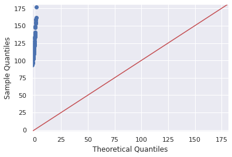

```python
#create Q-Q plot with 45-degree line added to plot
fig = sm.qqplot(update_df['Length'], line='45')
plt.show()
```

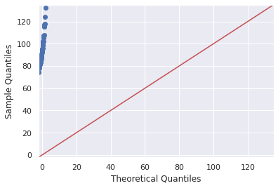

```python
#create Q-Q plot with 45-degree line added to plot
fig = sm.qqplot(update_df['Width'], line='45')
plt.show()
```

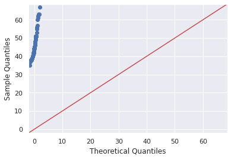

```python
#create Q-Q plot with 45-degree line added to plot
fig = sm.qqplot(update_df['Height'], line='45')
plt.show()
```

```python
log_df = update_df
for i in ['Length','Width','Height']:
    log_df[i]=np.log(update_df[i])
fit = MANOVA.from_formula('Length+Width+Height ~ sex', data=log_df)
print(fit.mv_test())
```

```
                    Multivariate linear model
==================================================================

------------------------------------------------------------------
       Intercept          Value   Num DF  Den DF  F Value   Pr > F
------------------------------------------------------------------
          Wilks' lambda    0.0006 3.0000 44.0000 22900.5812 0.0000
         Pillai's trace    0.9994 3.0000 44.0000 22900.5812 0.0000
 Hotelling-Lawley trace 1561.4033 3.0000 44.0000 22900.5812 0.0000
    Roy's greatest root 1561.4033 3.0000 44.0000 22900.5812 0.0000
------------------------------------------------------------------

-------------------------------------------------------------------
            sex            Value   Num DF   Den DF  F Value  Pr > F
-------------------------------------------------------------------
            Wilks' lambda  0.3510  3.0000  44.0000  27.1180  0.0000
           Pillai's trace  0.6490  3.0000  44.0000  27.1180  0.0000
   Hotelling-Lawley trace  1.8490  3.0000  44.0000  27.1180  0.0000
      Roy's greatest root  1.8490  3.0000  44.0000  27.1180  0.0000
==================================================================
```

## q5 results

In Q-Qplot, we know the normal assumption is not true. Our MANOVA is not correct model. After we took $log$. We know model reject $H_0$ this `length`, `width` and `height` are signifigant to sex.

# q6

```python
col_names = ['in560CM','in720CM','Species','Nutrient']
# read text file into pandas DataFrame
filename = "HW4_q6data.txt"
# df = pd.read_fwf(,header=None,names = col_names,delimiter = "\s")
# df
ll = []
with io.open(filename, mode="r", encoding="utf-8") as f:
    for line in f:
        # print(line.split())
        ll.append(line.split())

df = pd.DataFrame(ll,columns=col_names)
df['in560CM']=[float(i) for i in df['in560CM']]
df['in720CM']=[float(i) for i in df['in720CM']]
# from professesor, Species JP should change LP
df
```

|  | in560CM | in720CM | Species | Nutrient |
| --- | --- | --- | --- | --- |
| 0 | 10.35 | 25.93 | SS | + |
| 1 | 13.41 | 38.63 | JL | + |
| 2 | 7.78 | 25.15 | LP | + |
| 3 | 10.40 | 24.25 | SS | − |
| 4 | 17.78 | 41.45 | JL | − |
| 5 | 10.40 | 29.20 | LP | − |

```python
fit = MANOVA.from_formula("in560CM+in720CM ~ Species", data=df)
print(fit.mv_test())
```

```
                  Multivariate linear model
==============================================================

--------------------------------------------------------------
       Intercept         Value   Num DF Den DF F Value  Pr > F
--------------------------------------------------------------
          Wilks' lambda   0.0023 2.0000 2.0000 429.4225 0.0023
         Pillai's trace   0.9977 2.0000 2.0000 429.4225 0.0023
 Hotelling-Lawley trace 429.4225 2.0000 1.0000 214.7112 0.0482
    Roy's greatest root 429.4225 2.0000 2.0000 429.4225 0.0023
--------------------------------------------------------------

--------------------------------------------------------------
          Species          Value  Num DF Den DF F Value Pr > F
--------------------------------------------------------------
            Wilks' lambda  0.0159 4.0000 4.0000  6.9238 0.0438
           Pillai's trace  1.4034 4.0000 6.0000  3.5281 0.0824
   Hotelling-Lawley trace 35.4610 4.0000 2.0000  8.8653 0.1039
      Roy's greatest root 34.7024 2.0000 3.0000 52.0537 0.0047
==============================================================
```

## q6a1 results

The model reject $H_0$ according to **Wilks' lamba**. However, the P value is 0.0438 very close to $\alpha=0.05$ The `560CM` and `720CM` is signifigant to `Species`. But we might need to do further exploratin.

```python
fit = MANOVA.from_formula("in560CM+in720CM ~ Nutrient", data=df)
print(fit.mv_test())
```

```
                 Multivariate linear model
============================================================

------------------------------------------------------------
       Intercept         Value  Num DF Den DF F Value Pr > F
------------------------------------------------------------
          Wilks' lambda  0.0812 2.0000 3.0000 16.9782 0.0231
         Pillai's trace  0.9188 2.0000 3.0000 16.9782 0.0231
 Hotelling-Lawley trace 11.3188 2.0000 3.0000 16.9782 0.0231
    Roy's greatest root 11.3188 2.0000 3.0000 16.9782 0.0231
------------------------------------------------------------

------------------------------------------------------------
         Nutrient        Value  Num DF Den DF F Value Pr > F
------------------------------------------------------------
           Wilks' lambda 0.6114 2.0000 3.0000  0.9535 0.4780
          Pillai's trace 0.3886 2.0000 3.0000  0.9535 0.4780
  Hotelling-Lawley trace 0.6357 2.0000 3.0000  0.9535 0.4780
     Roy's greatest root 0.6357 2.0000 3.0000  0.9535 0.4780
============================================================
```

## q6a2 results

The model failed to reject $H_0$. The `560CM` and `720CM` is not signifigant to `Nutrient`.

```python
# start q6b
import statsmodels.api as sm
from statsmodels.formula.api import ols
```

```python
#perform two-way ANOVA
model = ols('in560CM ~ C(Species)+C(Nutrient)', data=df).fit()
sm.stats.anova_lm(model, typ=2)
```

|  | sum_sq | df | F | PR(>F) |
| --- | --- | --- | --- | --- |
| C(Species) | 47.476433 | 2.0 | 10.055087 | 0.090456 |
| C(Nutrient) | 8.260267 | 1.0 | 3.498902 | 0.202321 |
| Residual | 4.721633 | 2.0 | NaN | NaN |

```python
#perform two-way ANOVA
model = ols('in720CM ~ C(Species)+C(Nutrient)', data=df).fit()
sm.stats.anova_lm(model, typ=2)
```

|  | sum_sq | df | F | PR(>F) |
| --- | --- | --- | --- | --- |
| C(Species) | 262.238633 | 2.0 | 28.819649 | 0.033535 |
| C(Nutrient) | 4.489350 | 1.0 | 0.986746 | 0.425217 |
| Residual | 9.099300 | 2.0 | NaN | NaN |

## q6b results

We found the `560CM` against `Species` and `Nutrient` also failed to reject $H_0$. It means they are not signifigant like q6a.  
However, `720CM` in `Species` 3 groups shows the $\mu$ is signifigant. Take q6a1 result to compare, the influence factor is `720CM` rather than `560CM`.